# Assignment 4 - QBS 177

Spencer Bertsch  
Jan. 2022

Some helpful commands:  
* Insert a new code chunk: *Cmd+Option+I*  
* Run a code cell: *Cmd+Shift+Enter*  
* Preview the notebook HTML file: *Cmd+Shift+K*

### Imports

```r
library(glue)
library(qqman)
```

First we need to change our current working directory to the correct directory for Assignment 3

```r
setwd('/Users/spencerbertsch/Desktop/dev/phd_courses/MATH177/assignment4')
getwd()
```

```
[1] "/Users/spencerbertsch/Desktop/dev/phd_courses/MATH177/assignment4"
```

### Import the raw data

```r
load('lab1.Rdata')
```

Here we can transform the subpopulation data into 21 countries instead of 25. We need this to be the case later on

```r
chn <- (fulldat[,5] + fulldat[,6])/2
ind <- (fulldat[,11] + fulldat[,14])/2
nga <- (fulldat[,25] + fulldat[,8])/2
usa <- (0.777*fulldat[,4] + 0.132*fulldat[,2] + 0.053*(chn + ind + fulldat[,16] + fulldat[,15])/4)/(0.777+0.132+0.053)
fulldat <-fulldat[,c(3,1,5,7,9,12,11,24,15,17,19,25,21,20,22,18,13,23,10,4,16)]
fulldat[,3] <- chn
fulldat[,7] <- ind
fulldat[,12] <- nga
fulldat[,20] <- usa
```

The fulldat data frame now has only 21 columns.

We can now read in our response variable: the smoking data set

```r
yy <- read.delim("smoking_outcome.txt")
```

```r
y <- yy[,2]

# here we want to calculate the correlation between yy and the first 10000 loci
# we also want to know the p-values for each of the linear regressions run
plong <- corlong <- NULL

proc.time()
```

```
   user  system elapsed
  1.469   0.335   2.716
```

```r
for (i in 1:10000){

  # remove loci with all minor allele frequncy 0
  if(var(fulldat[i,])){

  # run a linear regression using the smoking data as the response and the i'th row of fulldat as the predictor
  fit <- lm(y~fulldat[i,])

  # find the correlation between the response variable and the i'th row of fulldat
  # (This is why they needed to be of the same dimension! 21 elements long)
  corlong[i] <- cor(fulldat[i,], y)

  #output slope from linear regression
  plong[i] <- summary(fit)$coef[2,4]
  }
}
proc.time()
```

```
   user  system elapsed
  4.022   0.366   5.300
```

This process took 2.54 seconds to finish, so if we assume that processing 10,000 records takes 2.54 seconds, then processing 1,099,146 samples would take 279.18 seconds, or about **4.65 minutes**.

We can now try to rewrite the above code without using a for loop so that we can improve the runtime of the algorithm.

```r
# n is the sample size
n <- dim(yy)[1]

# initialize a variable to store p values.
pvalue <- matrix(0, length(chr), 1)

# initialize a variable to store correlation.
corvalue <- matrix(0, length(chr), 1)

colnames(pvalue) <- c("prevave")
colnames(corvalue) <- c("prevave")
```

And we can now run the vector operation to obtain the same information, but without using a for-loop. Let’s see how much more quickly this process runs compared with the above process.

```r
proc.time()
```

```
   user  system elapsed
  4.031   0.373   5.315
```

```r
temp <- scale(t(fulldat))
y1 <- y/sqrt(var(y))

asd <- y1%*%temp/(n-1) # obtain correlation using apply
#asd <- suppressWarnings(apply( t(fulldat) , 2 , cor , y)) # alternative way

# mid step to calculate p value
asd1 <- 1-asd^2

# this is the T statistics
asd2 <- sqrt(n-2)*asd/sqrt(asd1)

# transform T statistics to p-value
pvalue[,1] <- 2*(1-pt(abs(asd2),(n-2)))

# pass correlation to corvalue.
corvalue[,1] <- asd
proc.time()
```

```
   user  system elapsed
  7.250   0.651   8.812
```

```r
abs(sum(plong-pvalue[1:10000], na.rm=T))
```

```
[1] 5.214536e-13
```

```r
abs(sum(corlong-corvalue[1:10000], na.rm=T))
```

```
[1] 2.177679e-13
```

And indeed we see that these two values are essentially zero, meaning that we were able to obtain the same correlations and p-values.

We now want to generate a manhattan plot so we can visualize our data. In order to do this, we need to have a dataframe that has 4 columns with the following names: 1. CHR 2. BP 3. SNP 4. P These columns allows the plotting function to create the manhattan plot. In order to make our Manhattan plot below, we need to create a data frame with the charactersitics mentioned above:

```r
# create dataframe with thefollwong chracteristics
index <- c(1:dim(pvalue)[1])
df1 <- data.frame(index, chr, pvalue, location)
```

We can use the below code to fill the NA values in the p-value vector in order to fix the bug in the plot

```r
# pvalue[is.na(pvalue[,1]), 1] <- mean(pvalue[,1], na.rm = TRUE)
# sum(is.na(pvalue))
# mu_new = colMeans(pvalue)
# print(mu_new)
# df1 <- data.frame(chr, pvalue, location)
```

Another option here instead of filling the p-values with the mean p-value is to simply drop the rows that have NAs in the position of p-values. It’s probably not a best practice to fill NAs for the results of statistical tests, so better to throw out the records that are missing the results so we can ignore them.

```r
print('We can find out how many NAs there are in our p-values:')
```

```
[1] "We can find out how many NAs there are in our p-values:"
```

```r
dim(df1)[1] - dim(df1[!is.na(df1$prevave),])[1]
```

```
[1] 24410
```

```r
df2 <- df1[!is.na(df1$prevave),]
```

## Question 1

Create a manhattan chart showing the resulting p-values and the ‘chr’ vector, and the ‘locaiton’ vector presented in the lab1.RData file:

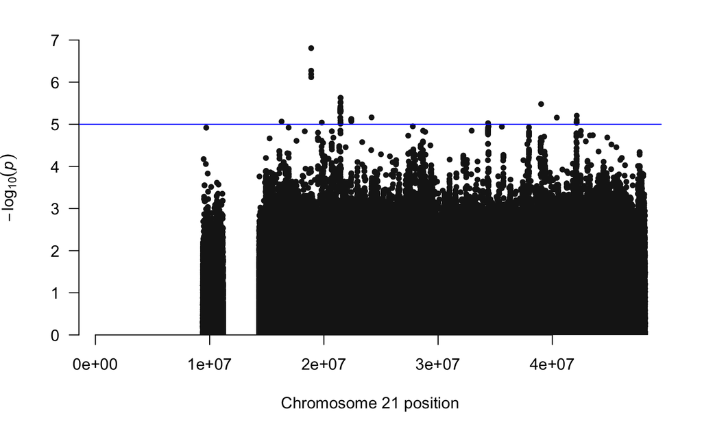

```r
# Make the Manhattan plot on the gwasResults dataset
manhattan(df2, chr="chr", bp="location", p="prevave", snp="location", col = c("gray10", "gray60"))
```

## Question 2

Identify top 9 locations on chromosome 21 based on the association p-values.

In order to answer this question we can take our newly created dataframe **df1** and sort it by p-value. Then we can take the top 9 rows and store the locations of those rows and use them to perform the online lookups to find the ‘rs’ number for the top 9 locations.

By “top locations’ here we mean the smallest p-values. If the model does a good job of fitting the data, then the p-value for the fit will be quite small. If there is no reasonable fit, then the p-value will be larger (closer to 1). We can then add an index column to our data and sort it by p-value in order to get the locations that correspond to the smallest 9 p-values.

```r
top_p_value_df <- df1[order(df1$prevave, decreasing=FALSE), ]
top_p_value_df
```

|  | index | chr | prevave | location |
| --- | --- | --- | --- | --- |
| 171220 | 171220 | 21 | 1.557500e-07 | 18887601 |
| 171210 | 171210 | 21 | 5.341077e-07 | 18887201 |
| 171218 | 171218 | 21 | 6.498068e-07 | 18887483 |
| 171381 | 171381 | 21 | 7.643547e-07 | 18892725 |
| 251471 | 251471 | 21 | 2.356621e-06 | 21460976 |
| 251473 | 251473 | 21 | 2.356621e-06 | 21460979 |
| 251399 | 251399 | 21 | 2.963624e-06 | 21458577 |
| 251385 | 251385 | 21 | 3.099801e-06 | 21458112 |
| 795183 | 795183 | 21 | 3.312984e-06 | 39016910 |
| 251062 | 251062 | 21 | 3.785508e-06 | 21447536 |

[output cut: 990 more lines]

This is the result of looking up each of the top 9 p-values on https://www.ncbi.nlm.nih.gov

| Chromosome | p-value | location | rs-number |
| --- | --- | --- | --- |
| 21 | 1.557500e-07 | 18887601 | rs7279313 |
| 21 | 5.341077e-07 | 18887201 | rs8129365 |
| 21 | 6.498068e-07 | 18887483 | rs8129817 |
| 21 | 7.643547e-07 | 18892725 | rs59660381 |
| 21 | 2.356621e-06 | 21460976 | rs78892776 |
| 21 | 2.356621e-06 | 21460979 | rs79009469 |
| 21 | 2.963624e-06 | 21458577 | rs78552707 |
| 21 | 3.099801e-06 | 21458112 | rs77095203 |
| 21 | 3.312984e-06 | 39016910 | rs1787423 |

These rs-numbers are the results of lookups for the locaitons that correspond with the smallest 9 p-values found above.

## Question 3

Draw scatter plot between smoking prevalence (y) and minor allele frequencies of each loci’s in 2. Add a regression line to the scatter plot. Add the correlation value to the plots as a legend. Use par(mfrow=c(3,3)) to plot all 9 figures in one plot.

We can examine our response variable here:

```r
# we have the response variable y:
yy
```

| Country | smoking.prevalence.in.. |
| --- | --- |
| Bangladesh | 20.55 |
| Barbados | 6.42 |
| China | 22.99 |
| Columbia | 10.77 |
| Finland | 17.58 |
| Gambia | 10.34 |
| India | 11.74 |
| Italy | 24.19 |
| Japan | 22.15 |
| Kenya | 8.88 |

[output cut: 11 more lines]

Now we need to get the minor allele frequencies for each of the top 9 records seen in question 2. We can do this by adding an index column into the dataframe and using that to index the correct rows out of the initial fulldat matrix.

```r
top_indices <- top_p_value_df[1:9, ]$index
print('These are the rows in the fulldat dataframe we want to plot against the response variable:')
```

```
[1] "These are the rows in the fulldat dataframe we want to plot against the response variable:"
```

```r
top_indices
```

```
[1] 171220 171210 171218 171381 251471 251473 251399 251385 795183
```

And finally we can get the correct rows out of the fulldat matrix that correspond to all of the p-values obtained from the processing above:

```r
# we can prepare our data here:
response <- yy[, 2]

maf_loci1 <- fulldat[top_indices[1],]
maf_loci2 <- fulldat[top_indices[2],]
maf_loci3 <- fulldat[top_indices[3],]
maf_loci4 <- fulldat[top_indices[4],]
maf_loci5 <- fulldat[top_indices[5],]
maf_loci6 <- fulldat[top_indices[6],]
maf_loci7 <- fulldat[top_indices[7],]
maf_loci8 <- fulldat[top_indices[8],]
maf_loci9 <- fulldat[top_indices[9],]
```

Now that we have our predictors and response variables defined, we can create the matrix of scatter plots:

```r
par(mfrow = c(3, 3))

# 1st plot
plot(maf_loci1, response, pch=16, col='red', cex=1.2, main='First plot')
abline(lm(response ~ maf_loci1), col='blue')
```

```r
c1 <- round(cor(maf_loci1, response, method = "pearson"), 3)
legend(0.12, 25, legend=c(c1),
       fill = c("blue","red")
)

# 2nd plot
plot(maf_loci2, response, pch=16, col='red', cex=1.2, main='Second plot')
```

```r
abline(lm(response ~ maf_loci2), col='blue')
c1 <- round(cor(maf_loci2, response, method = "pearson"), 3)
legend(0.125, 25, legend=c(c1),
       fill = c("blue","red")
)
```

```r
# 3rd plot
plot(maf_loci3, response, pch=16, col='red', cex=1.2, main='Third plot')
abline(lm(response ~ maf_loci3), col='blue')
```

```r
c1 <- round(cor(maf_loci3, response, method = "pearson"), 3)
legend(0.125, 25, legend=c(c1),
       fill = c("blue","red")
)

# 4th plot
plot(maf_loci4, response, pch=16, col='red', cex=1.2, main='Fourth plot')
```

```r
abline(lm(response ~ maf_loci4), col='blue')
c1 <- round(cor(maf_loci4, response, method = "pearson"), 3)
legend(0.125, 25, legend=c(c1),
       fill = c("blue","red")
)
```

```r
# 5th plot
plot(maf_loci5, response, pch=16, col='red', cex=1.2, main='Fifth plot')
abline(lm(response ~ maf_loci5), col='blue')
```

```r
c1 <- round(cor(maf_loci5, response, method = "pearson"), 3)
legend(0.09, 25, legend=c(c1),
       fill = c("blue","red")
)

# 6th plot
plot(maf_loci6, response, pch=16, col='red', cex=1.2, main='Sixth plot')
```

```r
abline(lm(response ~ maf_loci6), col='blue')
c1 <- round(cor(maf_loci6, response, method = "pearson"), 3)
legend(0.09, 25, legend=c(c1),
       fill = c("blue","red")
)
```

```r
# 7th plot
plot(maf_loci7, response, pch=16, col='red', cex=1.2, main='Seventh plot')
abline(lm(response ~ maf_loci7), col='blue')
```

```r
c1 <- round(cor(maf_loci7, response, method = "pearson"), 3)
legend(0.09, 25, legend=c(c1),
       fill = c("blue","red")
)

# 8th plot
plot(maf_loci8, response, pch=16, col='red', cex=1.2, main='Eighth plot')
```

```r
abline(lm(response ~ maf_loci8), col='blue')
c1 <- round(cor(maf_loci8, response, method = "pearson"), 3)
legend(0.09, 25, legend=c(c1),
       fill = c("blue","red")
)
```

```r
# 9th plot
plot(maf_loci9, response, pch=16, col='red', cex=1.2, main='Nineth plot')
abline(lm(response ~ maf_loci9), col='blue')
```

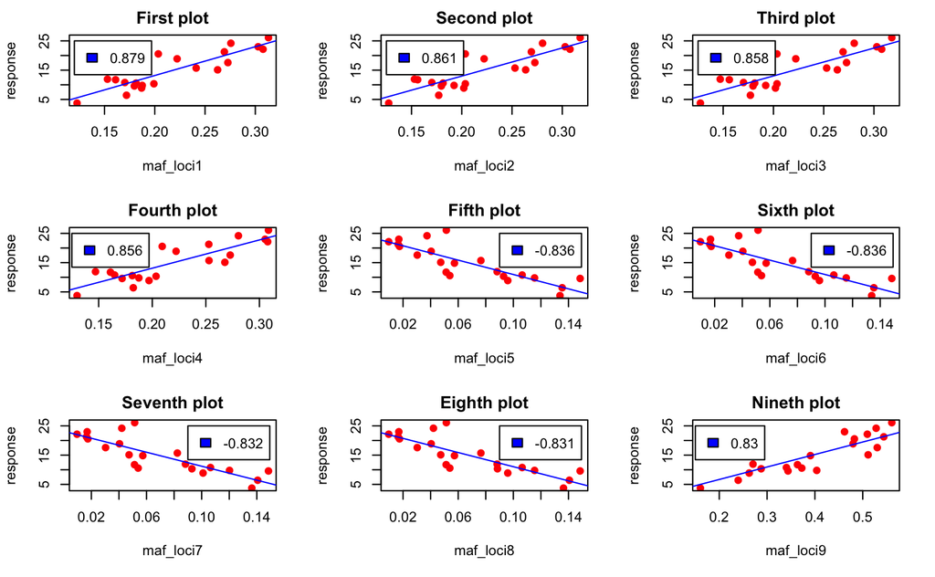

```r
c1 <- round(cor(maf_loci9, response, method = "pearson"), 3)
legend(0.15, 25, legend=c(c1),
       fill = c("blue","red")
)
```